La información corresponde al DENUE del 11 de noviembre de 2018 y que se encuentra en el INEGI

El sector 46 según el clasificador SCIAN de México se refiere al comercio al por menor, en la rama 462112 se encuentra el comercio al por menor en minisupers que incluye a las unidades económicas dedicadas principalmente “al comercio al por menor de alimentos, bebidas y productos de primera necesidad para los hogares y personas, organizados en secciones o pequeñas áreas de exhibición especializadas que facilitan el acceso directo del público a las mercancías, excluye al comercio al por menor de una amplia variedad de productos en tiendas de abarrotes, ultramarinos y misceláneas (461110, Comercio al por menor en tiendas de abarrotes, ultramarinos y misceláneas), y al comercio al por menor de productos en supermercados (462111, Comercio al por menor en supermercados)”

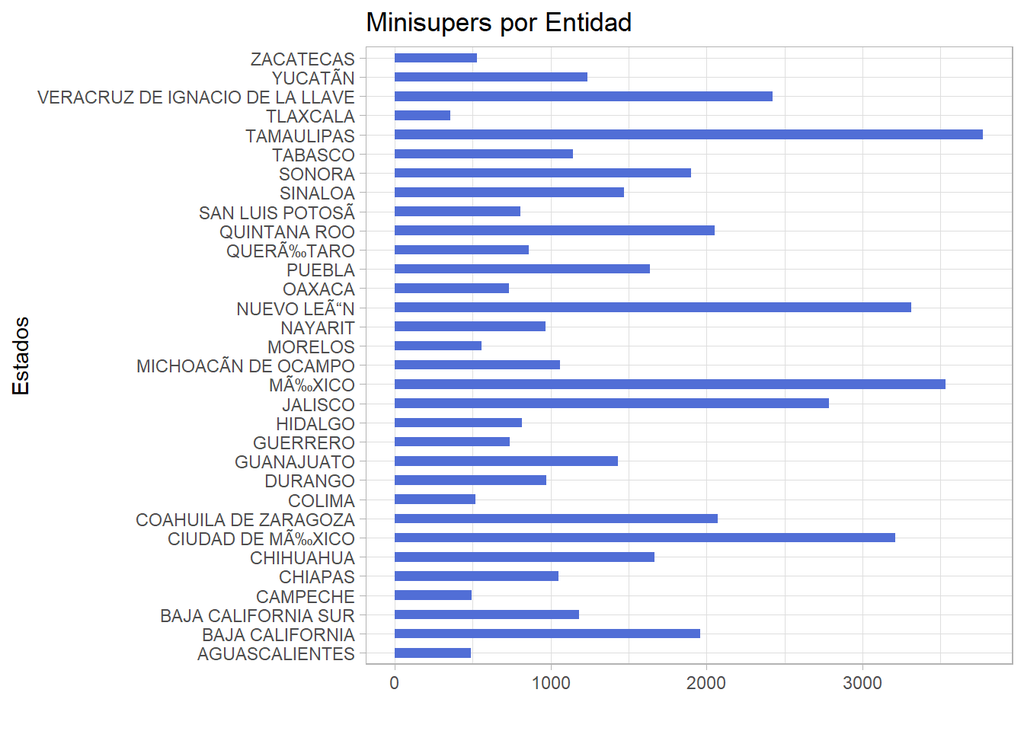

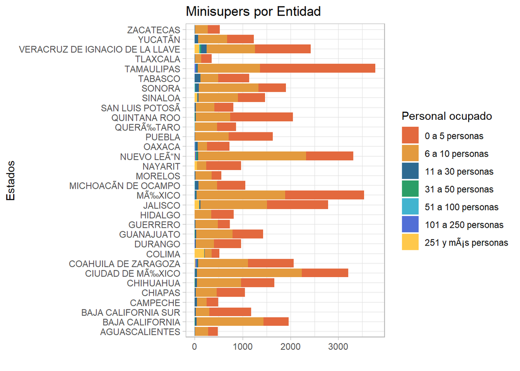

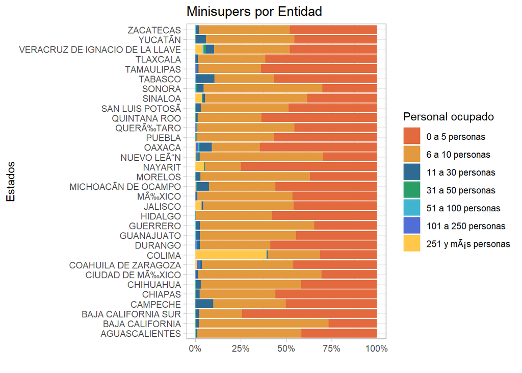

Las tiendas de conveniencia modificaron las formas de consumo, en lo que refiere a movilidad, desplazamiento, productos, horarios de compra y pago de servicios, se encuentran ahora en las carreteras, casetas de peaje, gasolineras, y pueden trabajar hasta 24 horas al día. Se seleccionaron y clasificaron las siguientes CADENAS, OXXO, Círculo K, 7 Eleven, SUPER K,SUPER CITY,GO MART,MAMBO,EXTRA,KIOSKO

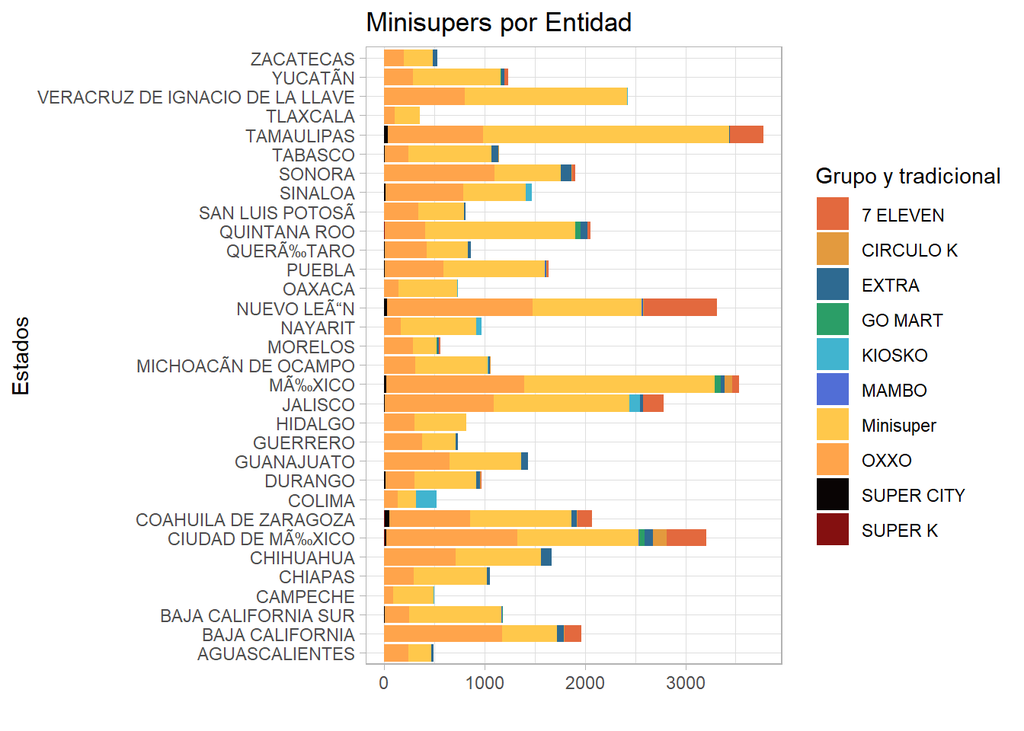

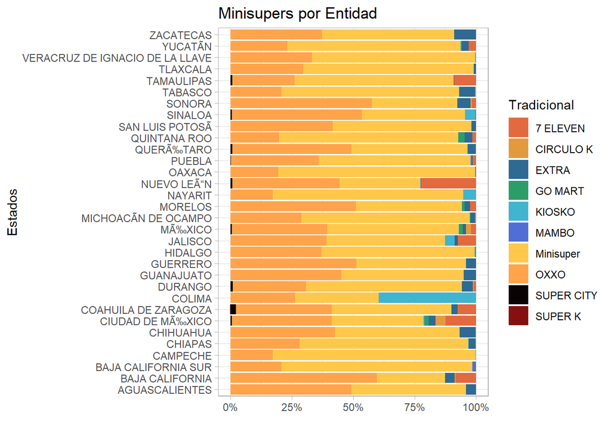

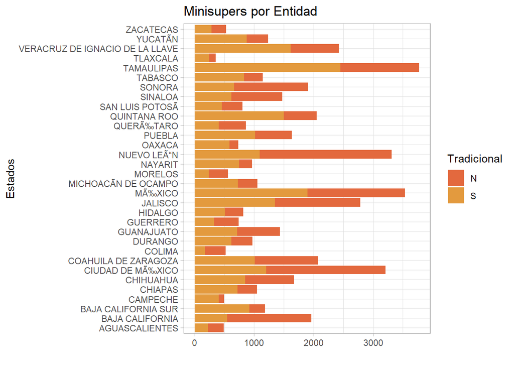

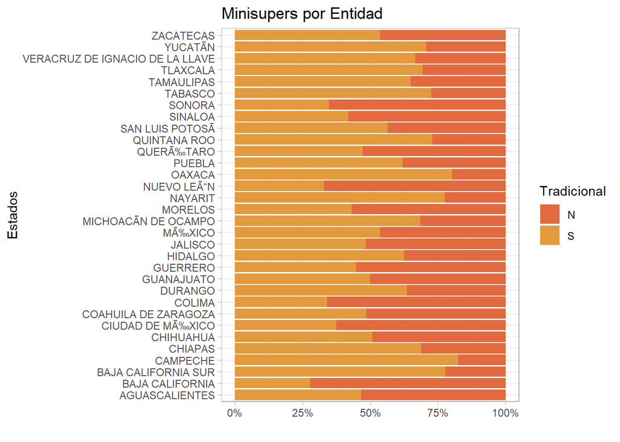

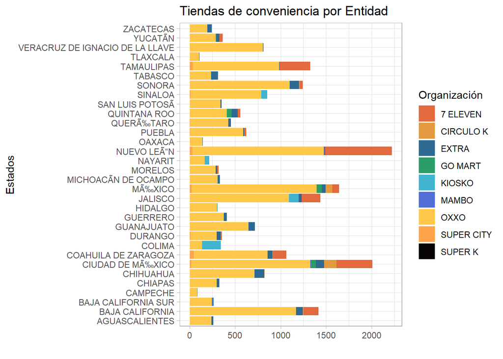

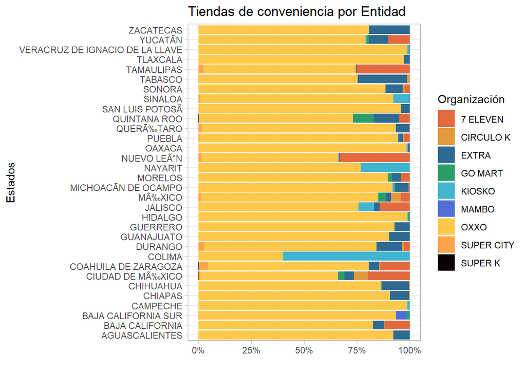

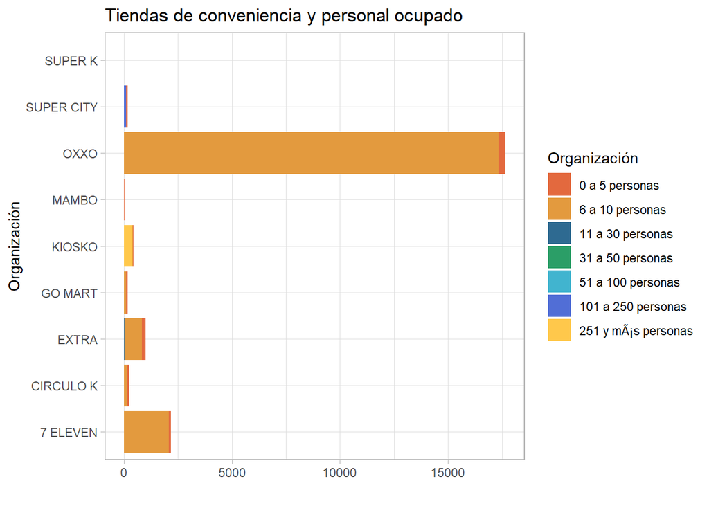

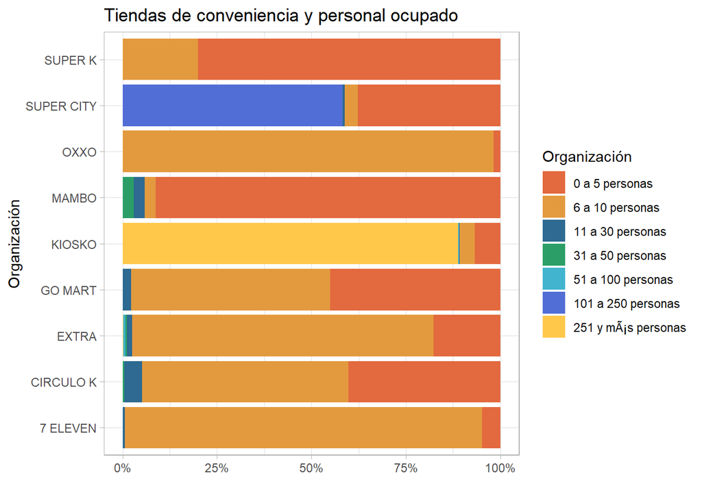

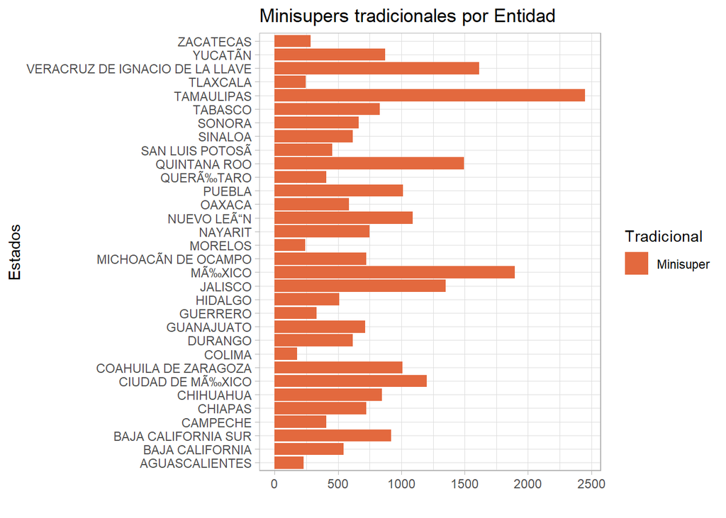

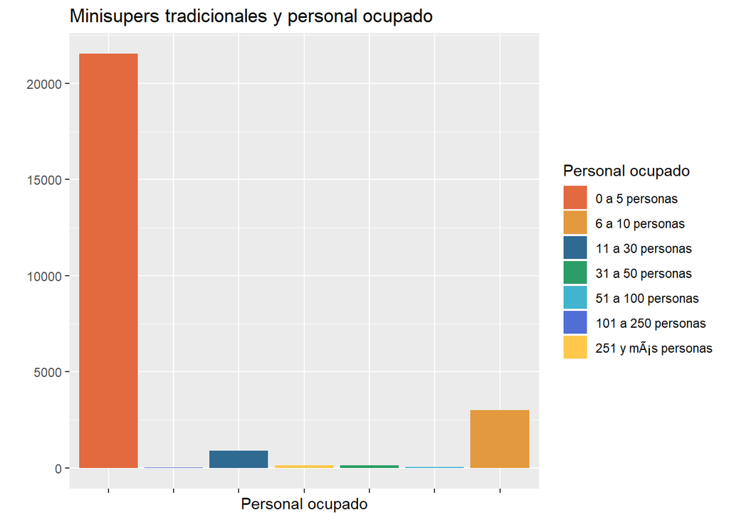

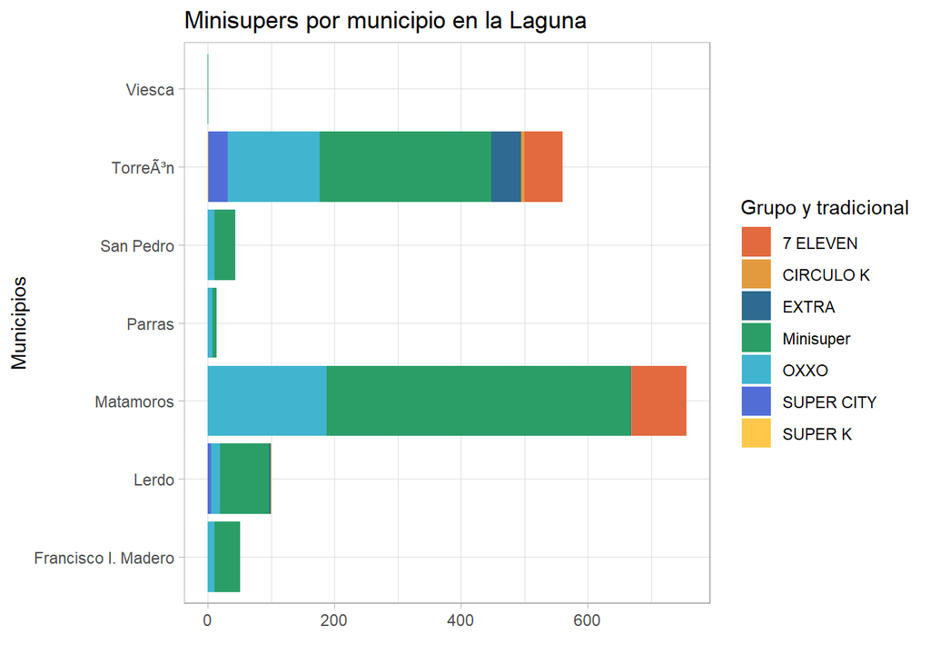

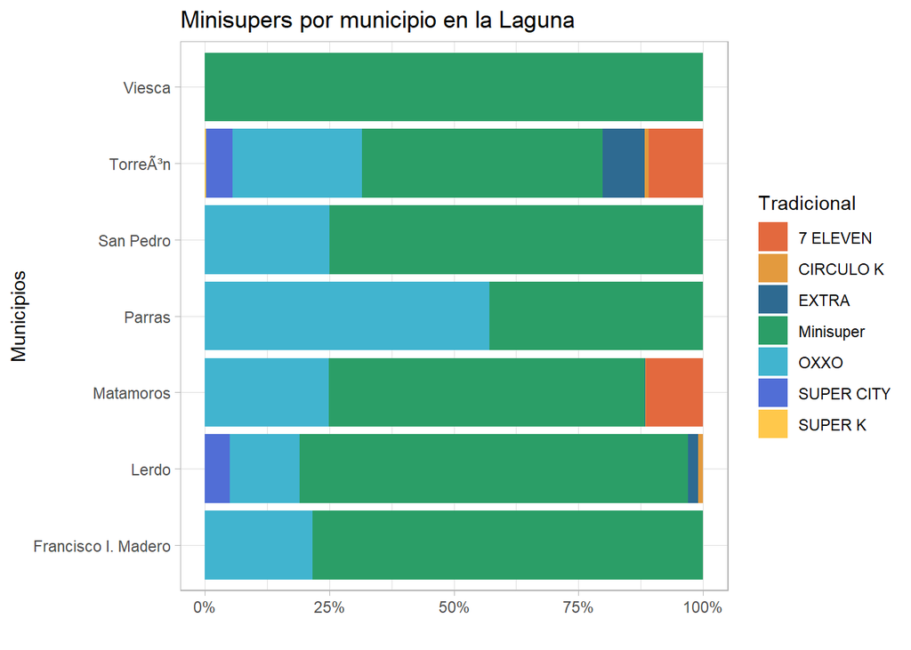

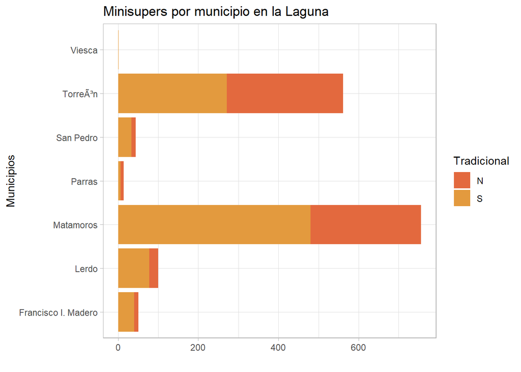

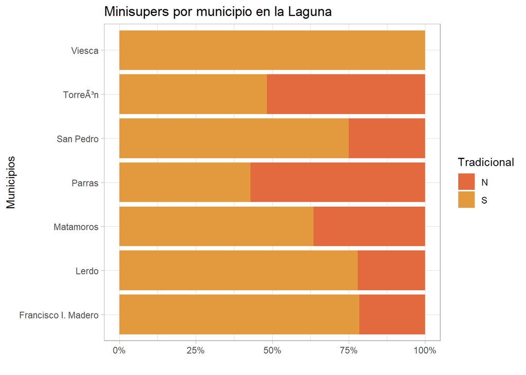

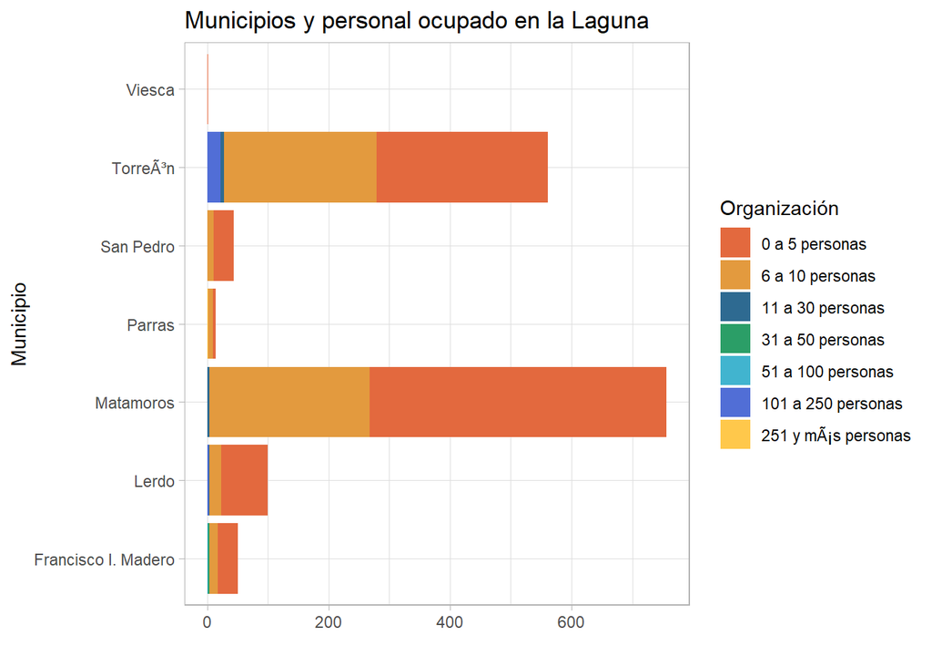

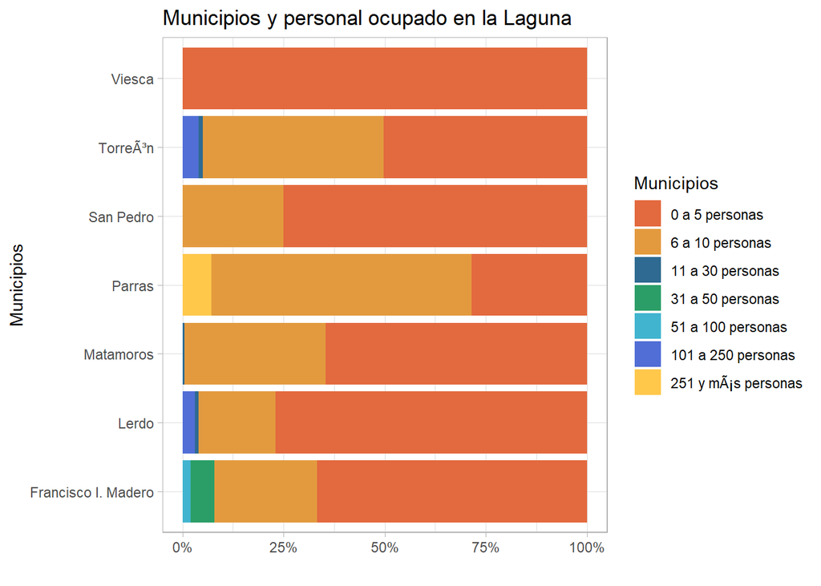

En esta apartado se presenta la situación de los municipios en el Estado de Coahuila de Zaragoza

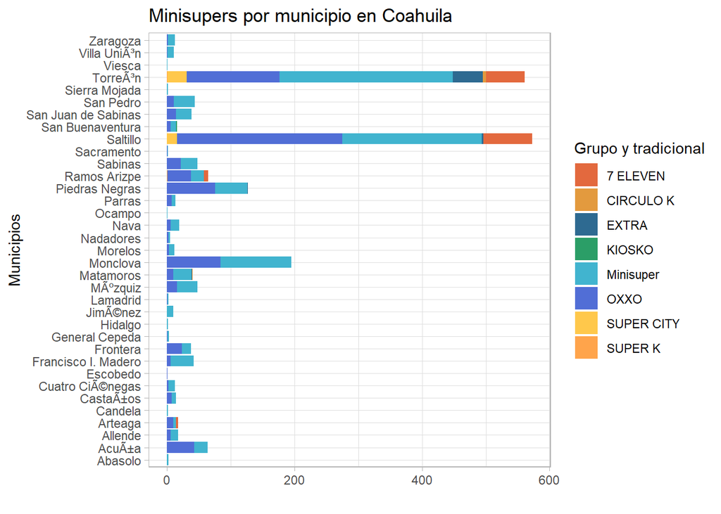

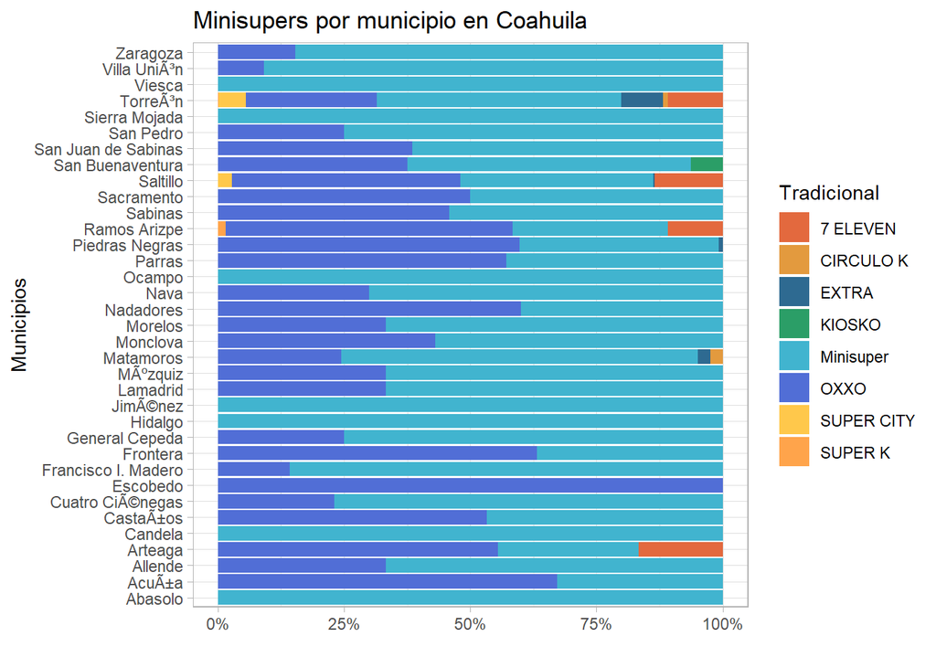

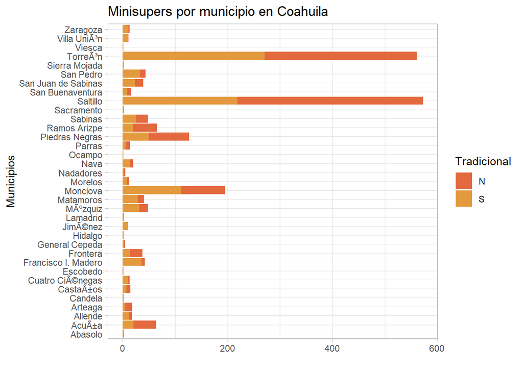

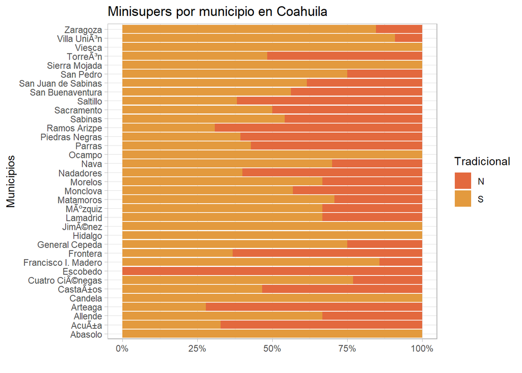

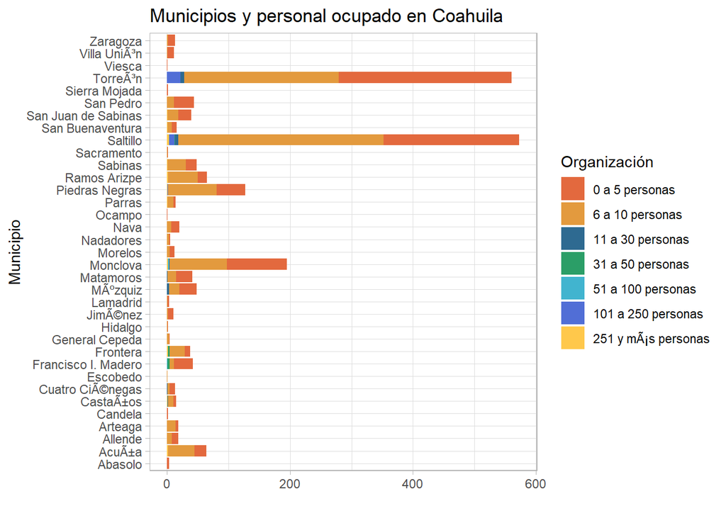

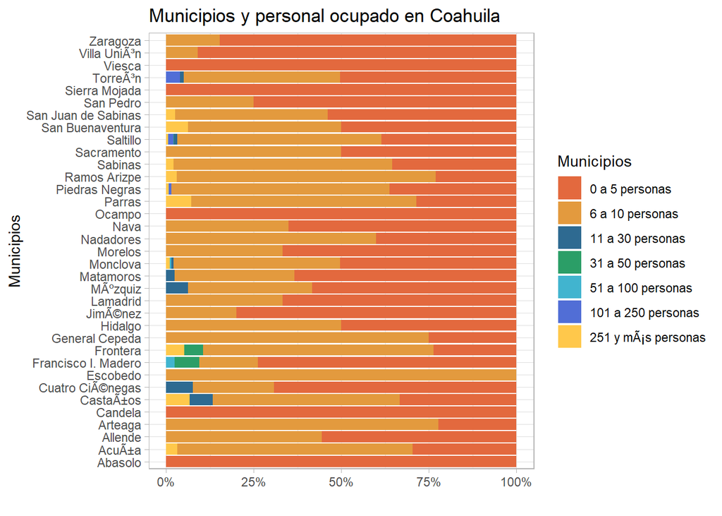

[output not shown]